# 데이터처리 실습 문제

hyo

2020 4 5

##### 문제1

- x = c(0.3113,0.22313,0.324,1.2) 벡터를 만든 후
  - 각 값들의 제곱의 지수값을 구한뒤
  - 소수 셋째 자리까지 반올림 하시오
  - `%>%` 연산자 사용

##### 문제2

- working directory에 있는 iris.csv를 읽는다
  - head()와 tail()을 활용하여 각 10개의 데이터씩 출력해보자

##### 문제3

- 위 iris 데이터에서 Name변수들이 어떤것들이 있는지 확인하시오
  - 각각의 갯수 확인해보시오
  - 확인 후 Name별 데이터를 만들어보시오

##### 문제4

- iris의Name을 그룹을 나누어 PetalWidth의 최댓값,최솟값을 구하시오
  - by를 사용
  - aggregate 사용

##### 문제5

- iris데이터에서 PetalWidth가 1.3이상인 데이터만을 추출 하여 SepalLength와 PetalWidth의 평균값을 `len`이라는 변수이름으로 파생변수를 생성해보시오
  - 변수는 PetalWidth와 SepalWidth 선택

##### 문제6

- iris데이터 변수 SepalLength, SepalWidth, PetalLength, PetalWidth에 대한 중앙값(median)을 Name별로 구하시오

##### 문제7

- 첫번째 표를 두번째 표형식으로 바꾸어라

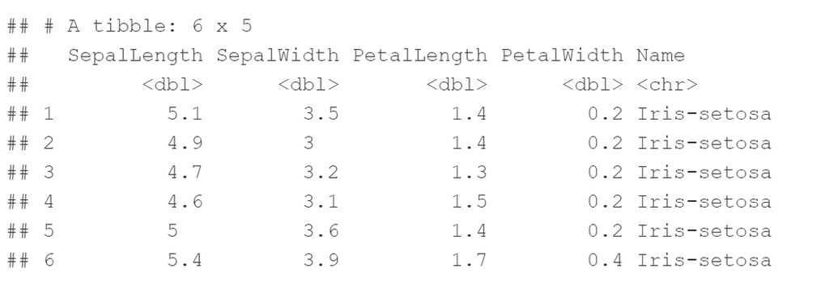

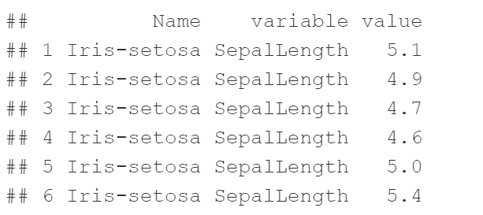

##### 문제8

- iris Name에서 `-`기준으로 iris, name을 분해하여 “iris”는 삭제하고 Name만 Name1 변수로 생성하시오

##### 문제9

- gold mining company, Freeport-McMoRan Inc. (FCX) 데이터 01-Jan-2015 to 18-Mar-2020기간의 데이터 이다
  - 데이터를 읽은 후 Date를 년(year),월(month),일(day)로 분해한 뒤 년,월 정보를 다시 합쳐 Date1만을 남긴다
  - 월이 10,11,12월의 데이터만을 추출
  - 종가(Adj_Close) 변수와 Date1변수만을 출력하시오

##### 문제10

- 아래 2개의 데이터를 만들어 tb1,tb2데이터를 Date1기준으로 테이블을 합치시오

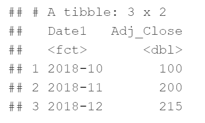

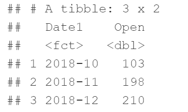